# Off The Grid: Efficient Trajectory Discovery with Adaptive Batch Sampling

## CRNGP in Practice

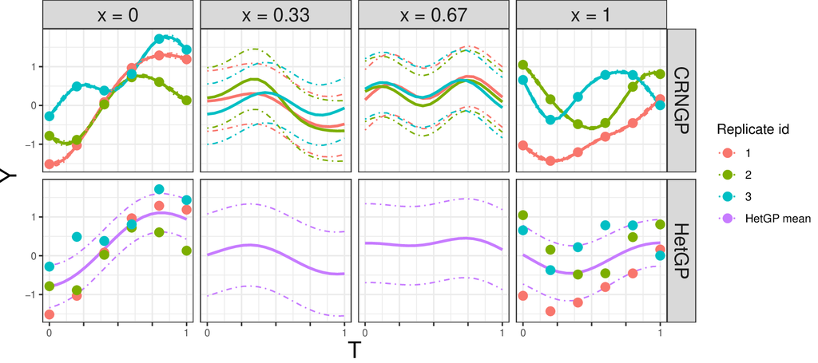

## Adaptive Grid Thompson Sampling

**Choose the next batch of $(x,r)$ pairs; refine where we search.**

### Sample

- Fit/update surrogate based on $f_n = \{ f(x_1, r_1), \ldots, f(x_n, r_n) \}$.
- Draw plausible response from the CRNGP posterior at many $(x_b,r_b)$:

$$\widetilde{f}(x_i,r_i) \sim p(f\mid\mathcal{f}_n)$$

### Select & simulate

- Each draw proposes a promising pair from the grid $\mathcal{G}_n$.
  $$(x_b,r_b)= \\ \arg\min_{(x,r)\in\mathcal{G}_n}
  | \widetilde{f}(x,r) - y_{\text{obs}} |$$
- Run new simulation at $(x_b,r_b)$
- Update CRNGP surrogate

### Adapt

- Refine the candidate grid:

$$\mathcal{G}_n \longrightarrow \mathcal{G}_{n+1}$$

Concentrate and add candidates near promising regions.

## Fixed Grid Thompson Sampling

[figure not shown]

First 1 iteration rows shown. Thompson Sampling iteratively selects $(x, r)$ candidates by sampling from the CRNGP posterior and picking the point with lowest predicted discrepancy.

## Fixed Grid Thompson Sampling

[figure not shown]

First 2 iteration rows shown. Thompson Sampling iteratively selects $(x, r)$ candidates by sampling from the CRNGP posterior and picking the point with lowest predicted discrepancy.

## Fixed Grid Thompson Sampling

[figure not shown]

First 3 iteration rows shown. Thompson Sampling iteratively selects $(x, r)$ candidates by sampling from the CRNGP posterior and picking the point with lowest predicted discrepancy.

## Fixed Grid Thompson Sampling

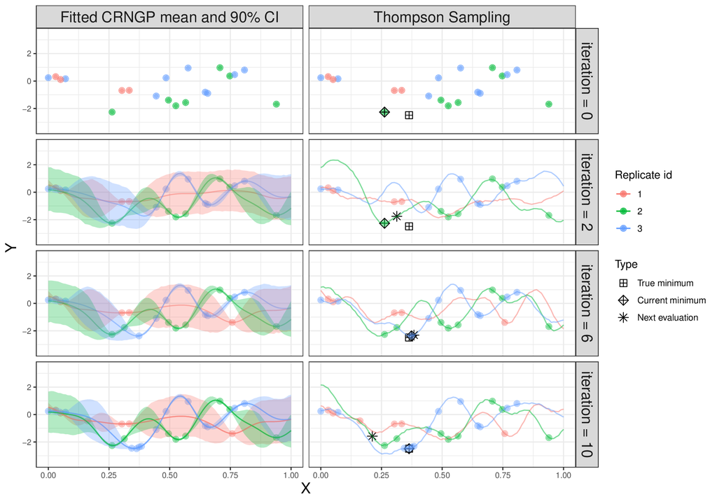

First 4 iteration rows shown. Thompson Sampling iteratively selects $(x, r)$ candidates by sampling from the CRNGP posterior and picking the point with lowest predicted discrepancy.

## Adaptive Grid Thompson Sampling

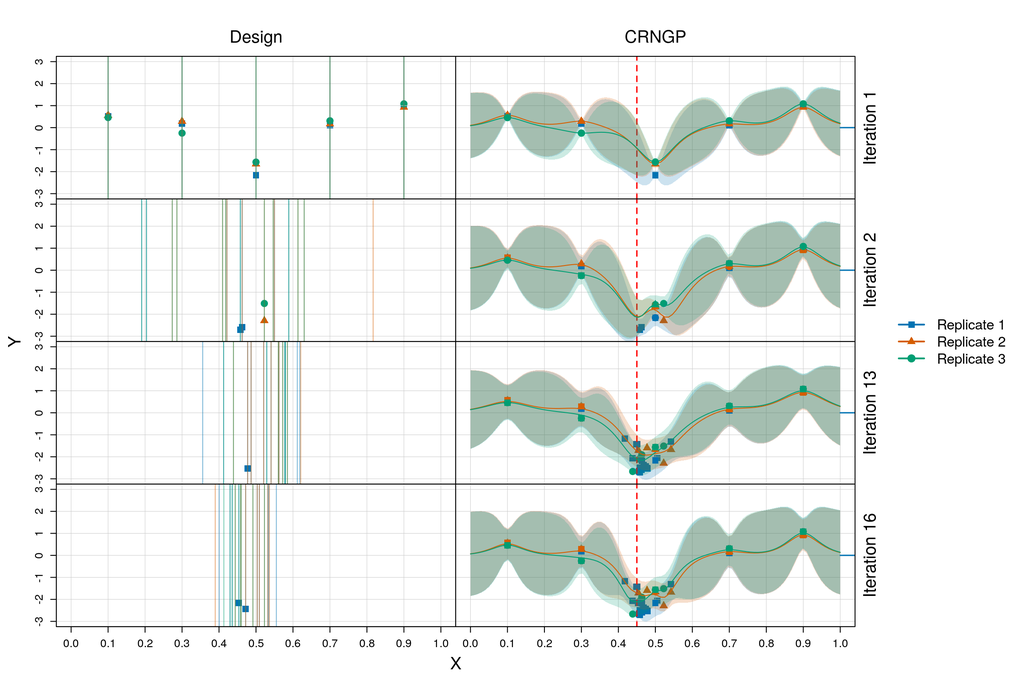

Illustration of adaptive grid TS with a CRNGP surrogate to find $(X, r)$ tuple having minimal $Y$ values.

## Result - Matching Trajectories

Stochastic SIR: multiple realizations reproduce the observed infection curve.

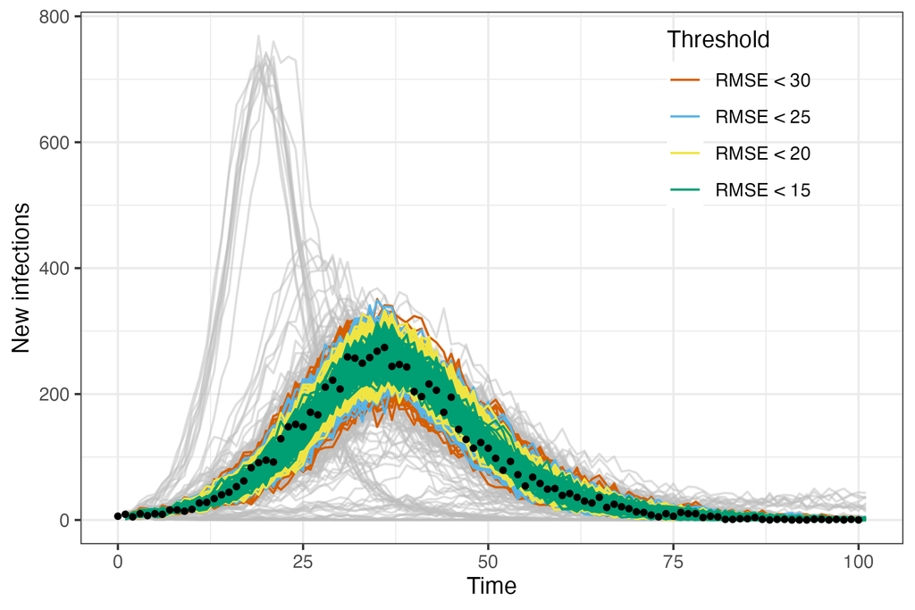

## Result - Exploring Inputs

aCRN explores an extended region of infection and recovery rates.

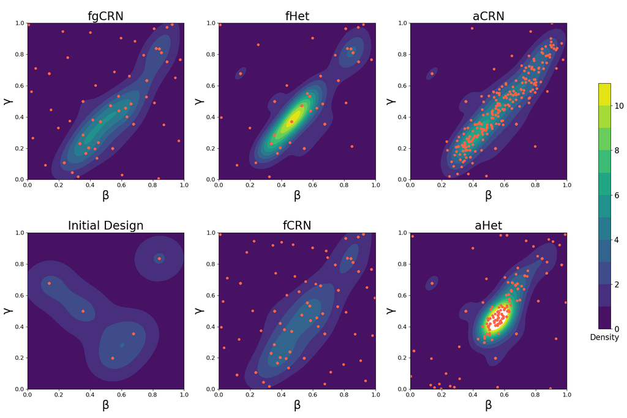

## Summary

- **Calibration matters downstream.** Missed historical matches can mean missed plausible futures.
- **Search for realizations.** TOO targets compatible $(x,r)$ pairs, rather than only a mean response.
- **Adaptive optimization approach.** aCRN combines a replicate-aware surrogate with adaptive grid Thompson sampling.
- **DMDU relevance:** carry diverse, data-consistent behaviors forward to stress-test policies across plausible futures.

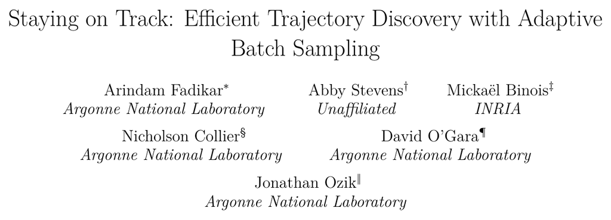

Preprint: [arXiv:2510.18099](https://arxiv.org/abs/2510.18099)

[figure not shown]